# Data Scientist Task for Stylight

Roland Matrahazi

2016.12.23.

## Ranking

At Stylight we measure the performance of millions of products and want to show the most relevant products to our users. To dip your toe into our daily work, please assign each product in the *product_scoring.csv* a “score” which you would suggest we should sort by. Here is an explanation of the fields:

*product_id*: The id of the product  
*category_id*: identifier of the category of the product  
*clicks*: The number of times this product was clicked  
*impressions*: The number of times this product was shown to users  
*cpc*: the amount of money we get per click

In addition to providing us with a score per product, please also explain the algorithm that you used to calculate this score (this is the most important part of this task). Also, explain current short comings and ideas for possible future improvements!

### Exploring the data

First we should have look at the data containing the products.

```r
# load data and libraries
library(data.table)
library(bit64) # to see long integers
library(ggplot2)
scoring = fread("product_scoring.csv", data.table = F)
str(scoring)
```

```
'data.frame':   10000 obs. of  5 variables:
 $ product_id : num  6.29e+18 7.51e+18 1.25e+17 1.94e+18 4.90e+18 ...
 $ category_id:Class 'integer64'  num [1:10000] 4.62e+175 6.22e-58 1.17e+88 4.62e+175 4.62e+175 ...
 $ cpc        : num  1.1 1.8 1.64 1.1 1.1 ...
 $ clicks     : num  0 0 2 0 0 5 0 0 0 0 ...
 $ views      : num  26 156 44 NA NA 120 NA NA 21 59 ...
```

```r
summary(scoring)
```

```
   product_id         category_id                       cpc            clicks             views
 Min.   :3.175e+11   Min.   :  18590165558100261   Min.   :1.094   Min.   :   0.000   Min.   :   20.0
 1st Qu.:2.251e+18   1st Qu.:3692024707650725577   1st Qu.:1.098   1st Qu.:   0.000   1st Qu.:   38.0
 Median :4.589e+18   Median :7234842626579207420   Median :1.638   Median :   0.000   Median :   79.0
 Mean   :4.585e+18   Mean   :5474718303513628712   Mean   :1.505   Mean   :   2.377   Mean   :  263.2
 3rd Qu.:6.890e+18   3rd Qu.:7234842626579207420   3rd Qu.:1.738   3rd Qu.:   0.000   3rd Qu.:  195.0
 Max.   :9.222e+18   Max.   :9097289594476179859   Max.   :2.600   Max.   :1095.000   Max.   :32168.0
                                                                                      NA's   :5561
```

We can see that 5 561 products have a missing value for their views. As I am not familiar with the data source I will give them the lowest rank and exlude them from further analysis. **Note:** In normal circumstances one should investigate this more especially as the csv contains only 10 000 products making the issue relevant!

Let’s have a look at the relationship between views and clicks:

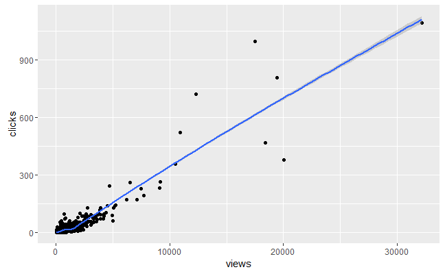

```r
scoringNoNAs = na.omit(scoring) # omitting rows with NAs
ggplot(data = scoringNoNAs, aes(views, clicks))+
  geom_point()+
  geom_smooth()
```

There seems to be some products with much higher views and clicks. These should be investigated as they will have a high rank if the data is reliable. Also, we see that there seems to be some relationship between the two variables which definitely makes sense.

We should have a closer look at the bottom-left corner as this part contains most products:

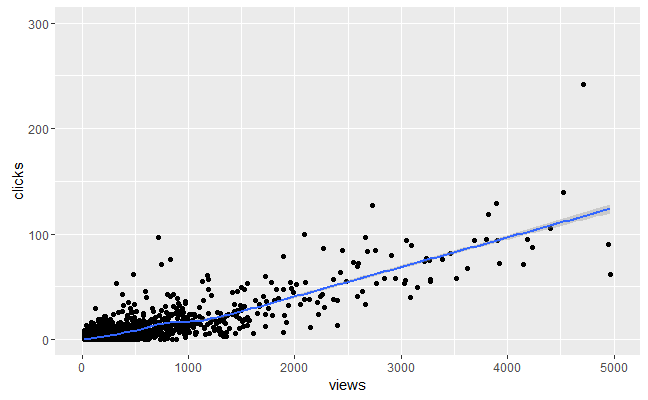

```r
ggplot(data = scoringNoNAs, aes(views, clicks))+
  geom_point()+
  geom_smooth()+
  xlim(0, 5000)+
  ylim(0,300)
```

Checking the correlation, being **0.9265484**, tells us that they are indeed highly interrelated.

We haven’t had a look at the cost-per-click variable so far which is key for revenue generation. The minimum (1.094) and maximum (2.600) seem reasonable but we should have some plots to analyse its distribution.

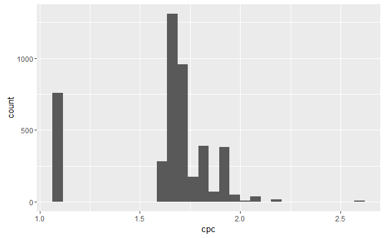

```r
qplot(cpc, data = scoringNoNAs)
```

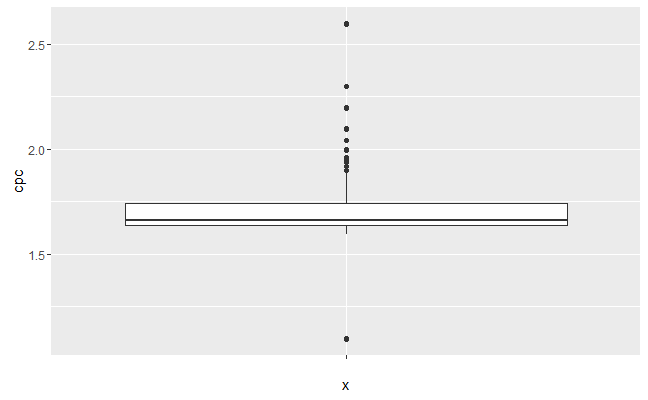

```r
qplot(cpc, x = '', data = scoringNoNAs, geom = 'boxplot')
```

We can see that while most products lie between 1.5 and 2.0 there seems to a significant bunch around 1.1. This is relevant as products with lower *cpc* need more clicks to produce the same amount of revenue.

### How to rank them

The simplest and most straightforward way to rank the products would be based on how much revenue they generate.  
We can calculate that by:

revenue = cpc * clicks

This assumes that we should show the products that are doing well. Also, we need a separate ranking for the whole list of products and separate rankings by category. First the customer lands at the page and later may choose a specific category (actually, one may check if selecting the most popular category is better than having a two-level ranking approach).

Before we rank the products let’s have a look at the distribution of revenue per product:

```r
scoringNoNAs$revenue = scoringNoNAs$cpc * scoringNoNAs$clicks
summary(scoringNoNAs$revenue)
```

```
    Min.  1st Qu.   Median     Mean  3rd Qu.     Max.
   0.000    0.000    0.000    9.151    5.088 1898.000
```

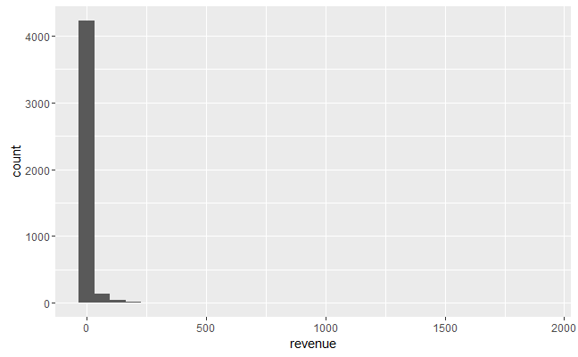

```r
qplot(revenue, data = scoringNoNAs)
```

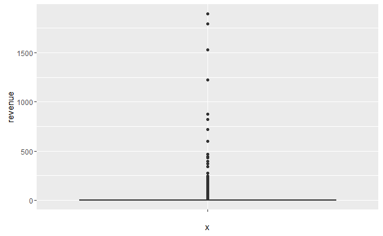

```r
qplot(revenue, x = '', data = scoringNoNAs, geom = 'boxplot')
```

Wow, most products bring in no revenue! Based on this and the information I gained so far of the data I propose the following algorithm for ranking:

1. Rank products by revenue (clicks * cpc)
2. Then rank products by views * cpc as we saw that views and clicks are highly correlated this measure might work as potential revenue for products with no clicks
3. Rank products by cpc with no views and clicks

Here I will do a global ranking but as I supposed we should create a separate ranking for every individual product category as well (eg. showing female t-shirts for someone clicking on male jeans makes no sense).  
Below we can see the code generating the ranking with smaller being better and also the top and bottom 100 respectively:

```r
scoring$views[is.na(scoring$views)] = 0 # fill NAs with zeroes
scoring$revenue = scoring$clicks * scoring$cpc
scoring$potentialRevenue = scoring$views * scoring$cpc
scoringOrdered = scoring[with(scoring, order(-revenue, -potentialRevenue, -cpc)),] # create ordered data frame
scoringOrdered$rank = 1:length(scoringOrdered$product_id) # create Rank variable
head(scoringOrdered, 100)
```

|  | product_id | category_id | cpc | clicks | views | revenue | potentialRevenue | rank |
| --- | --- | --- | --- | --- | --- | --- | --- | --- |
| 18 | 3.985574e+18 | 6224415035075099342 | 1.899988 | 999 | 17510 | 1898.08809 | 33268.7912 | 1 |
| 2992 | 6.837430e+17 | 3692024707650725577 | 1.638306 | 1095 | 32168 | 1793.94543 | 52701.0378 | 2 |
| 6573 | 5.529136e+18 | 9097289594476179859 | 1.896176 | 808 | 19418 | 1532.10988 | 36819.9376 | 3 |
| 5387 | 4.294393e+17 | 5547517019048776244 | 1.696891 | 722 | 12280 | 1225.15494 | 20837.8154 | 4 |
| 7211 | 2.417828e+18 | 4144838792376551216 | 1.675820 | 523 | 10940 | 876.45396 | 18333.4729 | 5 |
| 8305 | 3.697538e+18 | 4640986533030807114 | 1.755191 | 469 | 18406 | 823.18467 | 32306.0490 | 6 |
| 5692 | 8.309960e+18 | 7016191804580997334 | 1.896707 | 380 | 20039 | 720.74877 | 38008.1172 | 7 |
| 545 | 6.786993e+17 | 5468963934751397241 | 1.679672 | 359 | 10506 | 603.00216 | 17646.6314 | 8 |
| 1747 | 6.968865e+18 | 8511150219970800144 | 1.799016 | 259 | 6477 | 465.94508 | 11652.2250 | 9 |
| 7809 | 2.004414e+18 | 1949840533625410785 | 1.895492 | 233 | 9102 | 441.64966 | 17252.7692 | 10 |

[output cut: 90 more lines]

```r
tail(scoringOrdered, 100)
```

|  | product_id | category_id | cpc | clicks | views | revenue | potentialRevenue | rank |
| --- | --- | --- | --- | --- | --- | --- | --- | --- |
| 9703 | 1.675220e+18 | 7234842626579207420 | 1.094416 | 0 | 0 | 0 | 0 | 9901 |
| 9704 | 2.844742e+18 | 7234842626579207420 | 1.094415 | 0 | 0 | 0 | 0 | 9902 |
| 9705 | 2.966330e+18 | 7234842626579207420 | 1.094415 | 0 | 0 | 0 | 0 | 9903 |
| 9707 | 4.043121e+18 | 7234842626579207420 | 1.094414 | 0 | 0 | 0 | 0 | 9904 |
| 9710 | 2.370864e+18 | 7234842626579207420 | 1.094414 | 0 | 0 | 0 | 0 | 9905 |
| 9713 | 8.776086e+18 | 7234842626579207420 | 1.094412 | 0 | 0 | 0 | 0 | 9906 |
| 9714 | 8.114939e+18 | 7234842626579207420 | 1.094412 | 0 | 0 | 0 | 0 | 9907 |
| 9718 | 6.624478e+18 | 7234842626579207420 | 1.094411 | 0 | 0 | 0 | 0 | 9908 |
| 9719 | 3.034468e+18 | 7234842626579207420 | 1.094409 | 0 | 0 | 0 | 0 | 9909 |
| 9725 | 6.256394e+18 | 7234842626579207420 | 1.094405 | 0 | 0 | 0 | 0 | 9910 |

[output cut: 90 more lines]

**NOTE:** In this example I did not take into account demand curves as we can assume that popularity plateaus out and then showing a product with lower views and clicks may produce more revenue.

## A/B test analysis

We develop new features at Stylight, we want to make sure that our users like them. For this reason, we usually perform A/B tests. In this task, please have a look at the files clicks_per_session_a.csv & clicks_per_session_b.csv. In these you will find the results of an A/B test.  
Please evaluate the results and tell us:  
- Did one version have better results than the other?  
- And if yes, how confident are you?  
This task is hard and even if you don’t finish it, please summarize your thoughts up to the point where you got and give us a rough overview what’s missing.  
Hint: The underlying distribution is not a normal distribution

### Exploring the differencces of the two groups

Let’s have a quick look at the data, first session A:

```r
sessionA = fread("clicks_per_session_a.csv", data.table = F)
str(sessionA)
```

```
'data.frame':   227220 obs. of  2 variables:
 $ session_id:Class 'integer64'  num [1:227220] 5.00e+85 1.84e-305 1.49e-102 2.91e+242 1.15e+158 ...
 $ clicks    : int  0 0 0 0 0 3 0 0 1 1 ...
```

```r
summary(sessionA)
```

```
   session_id                      clicks
 Min.   :     43018645413338   Min.   :  0.000
 1st Qu.:2322002690506135086   1st Qu.:  0.000
 Median :4617940430626891113   Median :  0.000
 Mean   :4616622772325340295   Mean   :  1.037
 3rd Qu.:6914392218531277983   3rd Qu.:  1.000
 Max.   :9223252857012817323   Max.   :343.000
```

Next session B:

```r
sessionB = fread("clicks_per_session_b.csv", data.table = F)
str(sessionB)
```

```
'data.frame':   227168 obs. of  2 variables:
 $ session_id:Class 'integer64'  num [1:227168] 6.08e+240 1.16e-66 1.16e-97 1.26e+243 1.35e+262 ...
 $ clicks    : int  8 0 2 0 1 0 0 0 1 0 ...
```

```r
summary(sessionB)
```

```
   session_id                      clicks
 Min.   :    194857575324267   Min.   :  0.000
 1st Qu.:2307024035408314945   1st Qu.:  0.000
 Median :4586601189645384474   Median :  0.000
 Mean   :4599348232698751415   Mean   :  1.036
 3rd Qu.:6901518847307382291   3rd Qu.:  1.000
 Max.   :9223282259261367831   Max.   :114.000
```

**Remarks:**  
- We can see that both groups have around 227 000 observations  
- The data only includes a session ID and click counts  
- Based on just clicks we have no idea of the produced (or potential) revenue  
- The means of the two groups seem identical (respectively 1.037 and 1.036) **NOTE:** My analysis must be limited as the design of the experiment including sampling of the population is relevant and I don’t have access to this information.

To test the difference of two groups we need to identify the distributions and then use some statistical test. Visualising the distributions:

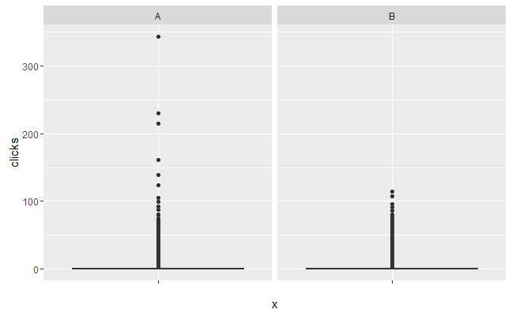

```r
sessionA$group = "A"
sessionB$group = "B"
both = rbind(sessionA, sessionB)
d = ggplot(both, aes(x = '', y = clicks))+
  geom_boxplot()
d+facet_grid(.~ group)
```

The boxplots show that session A has some higher values but it does not have a big impact as the means are very similar.

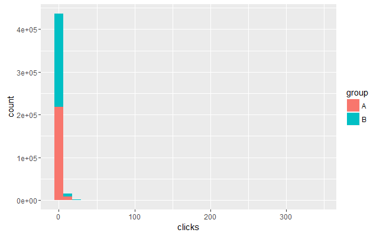

```r
ggplot(both, aes(clicks))+
  geom_histogram(aes(fill = group))
```

The histogram and the nature of the data (integer counts) could suppose a Poisson distribution but the variance of the clicks in both groups don’t comply with this theory (respectively 7.9043477 and 6.7595089).

We can use a qqplot to see how the quantiles of the two distributions correspond.

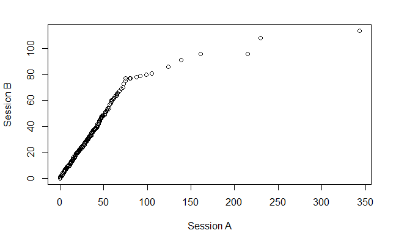

```r
qqplot(sample(sessionA$clicks, 227000), sample(sessionB$clicks, 227000), xlab = "Session A", ylab = "Session B")
```

The plot shows that disregarding the few extreme values from Session A the two distribution look identical (to create the plot I needed same number of observations so I sampled 227 000 from both).

To conclude we can say that we can’t see much difference in the two groups, with an almost identical expected value (mean), thus they have a similar result. To give a confidence level I would need to identify the population distributions.